# Nonrigorous solutions and domain of analyticity

Dr. Andrew D. Burbanks, 2019.

> This notebook requires a Python 3 kernel and the Pathos multiprocessing package. Version numbers of packages used are provided at the bottom of the notebook.

> Multi-precision decimal arithmetic is used to find good approximate fixed points, and other quantities, to be used in the rigorous computations in the accompanying notebook.

> Example results are shown in the outputs of the cells for the case $N=40$. Generated figures are included, but the flag for generating them is switched off in order to avoid excessive running times.

```python
d = 4
N = prec = 40
draw_figures = False #True
```

```python
from decimal import Decimal, getcontext
RR = Decimal
getcontext().prec = prec
```

```python
from numpy import zeros, array, dot, shape
from numpy.linalg import inv, solve
```

```python
from itertools import zip_longest

class Poly1:
    def __init__(self, coeffs, domain=(RR(0), RR(1))):
        self.domain = array(domain, dtype=RR)
        self.coeffs = array(list(map(RR, coeffs)), dtype=RR)
    @property
    def coef(self):
        return self.coeffs
    def __repr__(self):
        return f'Poly1(coeffs={self.coeffs!r}, domain={self.domain!r})'
    def __len__(self):
        return len(self.coeffs)
    def __getitem__(self, ind):
        return self.coeffs[ind]
    def degree(self):
        return len(self)-1
    def __pos__(self):
        return Poly1(self.coeffs, domain=self.domain)
    def __neg__(self):
        return Poly1(-self.coeffs, domain=self.domain)
    def __add__(self, x):
        if isinstance(x, Poly1):
            assert all(self.domain == x.domain)
            coeffs = (a+b for (a,b) in zip_longest(self, x, fillvalue=RR(0)))
            return Poly1(coeffs, domain=self.domain)
        else:
            coeffs = array(self.coeffs)
            coeffs[0] += x
            return Poly1(coeffs, domain=self.domain)
    def __sub__(self, x):
        return self+(-x)
    def __mul__(self, x):
        if isinstance(x, Poly1):
            assert all(self.domain == x.domain)
            coeffs = zeros(min(N+1, 1+self.degree()+x.degree()), dtype=RR)
            for j, a in enumerate(self):
                for k, b in enumerate(x):
                    if j+k <= N:
                        coeffs[j+k] += a*b
            return Poly1(coeffs, domain=self.domain)
        elif x==0:
            return Poly1([], domain=self.domain)
        else:
            return Poly1([a*x for a in self.coeffs], domain=self.domain)
    def __truediv__(self, x):
        if isinstance(x, Poly1):
            raise NotImplementedError
        else:
            return Poly1([a/x for a in self.coeffs], domain=self.domain)
    def __pow__(self, k):
        assert isinstance(k, int)
        assert k >= 0
        prod = Poly1([RR(1)], domain=self.domain)
        pow2 = self
        while k>0:
            if k%2 == 1:
                prod = prod*pow2
            k //= 2
            pow2 = pow2*pow2
        return prod
    def __radd__(self, x):
        return self+x
    def __rsub__(self, x):
        return -(self-x)
    def __rmul__(self, x):
        return self*x
    def __call__(self, x):
        c, r = self.domain
        u = (x - c)/r
        if isinstance(u, Poly1):
            total = u*0
        else:
            total = RR(0)
        for a in reversed(self.coeffs):
            total = total * u
            total = total + a
        return total
    def identity(self, domain):
        c, r = domain
        return Poly1([c, r], domain=domain)
    def truncate(self, n):
        self.coeffs = self.coeffs[:min(len(self), n)]
        return self
    def deriv(self):
        c, r = self.domain
        return Poly1([(k+1)*a for (k, a) in enumerate(self.coeffs[1:])], domain=self.domain)/r
```

```python
def coeffs(p):
    assert isinstance(p, Poly1)
    c = zeros(N+1, dtype=RR)
    m = min(N+1, len(p.coef))
    c[:m] = p.coef[:m]
    return c
```

```python
def l1_norm(p):
    assert isinstance(p, Poly1)
    return sum(abs(p.coef))
```

```python
def basis_vector(k):
    e_k = zeros(k+1, dtype=RR)
    e_k[k] = RR(1)
    return Poly1(e_k, domain=(c,r))
```

```python
def matrix_elements(L):
    jac = zeros((N+1, N+1), dtype=RR)
    for k in range(N+1):
        e_k = basis_vector(k)
        Le_k = L(e_k)
        jac[:,k] = coeffs(Le_k)
    return jac
```

```python
def solve(A, b):
    m, n = shape(A)
    try:
        o, p = shape(b)
    except ValueError:
        o, p = len(b), 1
    assert m == n
    assert m == o
    A_aug = zeros((m, n+p), dtype=RR)
    A_aug[:,:n] = A
    A_aug[:,n:] = b.reshape(o, p)
    for k in range(n):
        pivot = k
        for l in range(k+1, n):
            if abs(A_aug[l,k]) > abs(A_aug[pivot,k]):
                pivot = l
        if pivot != k:
            A_aug[[k, pivot],:] = A_aug[[pivot, k],:]
        for j in range(n):
            if j != k:
                A_aug[j] -= A_aug[k]*A_aug[j,k]/A_aug[k,k]
                A_aug[j, k] = RR(0)
        A_aug[k] = A_aug[k]/A_aug[k,k]
    if p == 1:
        return A_aug[:,-1]
    else:
        return A_aug[:,n:]
```

```python
def identity(n):
    I = zeros((n, n), dtype=RR)
    for k in range(n):
        I[k, k] = RR(1)
    return I
```

```python
def inv(A):
    m, n = shape(A)
    assert m == n
    I = zeros((m, n), dtype=RR)
    for k in range(n):
        I[k, k] = RR(1)
    return solve(A, I)
```

```python
def make_Phi(F, DF):
    def Phi(G):
        A, b = matrix_elements(DF(G)), coeffs(F(G))
        soln = solve(A, b)
        delta_G_coef = -soln
        delta_G = Poly1(delta_G_coef, domain=G.domain)
        return G + delta_G
    return Phi
```

```python
def newton_steps(F, Phi, G0):
    err0 = l1_norm(F(G0))
    for k in range(1, 100):
        G1 = Phi(G0)
        err1 = l1_norm(F(G1))
        # only print and accept if better
        if err1 < err0:
            print(err1)
            G0 = G1
            err0 = err1
        else:
            break
    return G0
```

## Feigenbaum fixed-point function and its derivative

```python
domains = {2: (RR('1'), RR('2.5')),
           4: (RR('0.5754'), RR('0.8'))}

c, r = domains[d]
```

```python
def Q(x):
    return x**d
```

We consider the renormalisation operator $$ Tf(x) = a^{-1}f(f(ax)), $$ in which $a=a(f)$ is chosen so as to enforce a suitable normalisation. We choose the normalisation $f(0)=1$, for which a number of different choices for $a$ are possible leading to operators with slightly different properties, and a corresponding variant of the operator with $a:=f(1)$.

Since we are interested in functions of $x^d$ for even integer $d$, we write $g(x)=G(x^d)$. Letting $X=Q(x)=x^d$, we therefore seek a function $G(X)$ that satisfies the corresponding fixed-point equation $$ G(X) = a^{-1}G(Q(G(a^dX))),\quad a:=G(1). $$ From now on, we let $T$ denote the operator that maps $G(X)$ to the right-hand side of the corresponding fixed-point equation: $$ T(G(X)) = a^{-1}G(Q(G(a^dX))),\quad a:=G(1). $$

```python
def T(G):
    a = G(1)
    X = G.identity(domain=G.domain)
    TG = a**-1*G(Q(G(X*a**d)))
    return TG
```

We note first that the fixed points of ${T}$ are exactly the zeros of the operator defined by $$ {F} = {T}-{I}. $$ Newton's method for zeros of ${F}$ may be written as \begin{align} \mathcal{N}: G &\mapsto G - [D{F}(G)]^{-1}[{F}(G)]. \end{align} Here, we perform the method nonrigorously, i.e., numerically, using truncated power series and floating-point arithmetic with rounding errors. We have,

\begin{align} D{T}(G):\delta G(X)\mapsto &-a^{-2}\delta a \cdot G(Q(G(a^dX)))\\ &\quad{}+ a^{-1}\cdot\delta G(Q(G(a^dX)))\\ &\qquad{}+ a^{-1}\cdot G'(Q(G(a^dX)))\cdot Q'(G(a^dX))\cdot\delta G(a^dX)\\ &\qquad\quad{}+ a^{-1}\cdot G'(Q(G(a^dX)))\cdot Q'(G(a^dX))\cdot G'(a^dX)\cdot Q'(a)\delta a X, \end{align}

where $a:=G(1)$ implies that $\delta a=\delta G(1)$.

```python
def DT(G):
    a = G(1)
    X = G.identity(domain=G.domain)
    Xad = X*a**d
    GXad = G(Xad)
    QGXad = Q(GXad)
    GQGXad = G(QGXad)

    Gdash = G.deriv()
    GdashXad = Gdash(Xad)
    GdashQGXad = Gdash(QGXad)

    # compute parts independent of H
    t1 = -a**-2*GQGXad
    t2 = a**-1
    t3 = a**-1*GdashQGXad*d*GXad**(d-1)
    t4 = t3*GdashXad*d*a**(d-1)*X

    def DTG(H):
        assert all(G.domain == H.domain)
        da = H(1)
        term1 = t1*da
        term2 = t2*H(QGXad)
        term3 = t3*H(Xad)
        term4 = t4*da
        DTGH = term1 + term2 + term3 + term4
        return DTGH

    return DTG
```

```python
def DT_naive(G):
    a = G(1)
    X = G.identity(domain=G.domain)
    Xad = X*a**d
    GXad = G(Xad)
    QGXad = Q(GXad)
    GQGXad = G(QGXad)

    Gdash = G.deriv()
    GdashXad = Gdash(Xad)
    GdashQGXad = Gdash(QGXad)

    t2 = a**-1
    t3 = a**-1*GdashQGXad*d*GXad**(d-1)

    def DTG_naive(H):
        assert all(G.domain == H.domain)
        term2 = t2*H(QGXad)
        term3 = t3*H(Xad)
        DTGH = term2 + term3
        return DTGH

    return DTG_naive
```

```python
def F(G):
    return T(G)-G
```

$$ DF(G):\delta G\mapsto DT(G)\delta G-\delta G. $$

```python
def DF(G):
    DTG = DT(G)
    def DFG(H):
        return DTG(H) - H
    return DFG
```

```python
def DF_naive(G):
    DTG = DT_naive(G)
    def DFG(H):
        return DTG(H) - H
    return DFG
```

```python
%matplotlib inline
import matplotlib.pyplot as plt
import numpy as np

if False:

    def make_f(mu):
        def f(x):
            return 1 - mu*x**d
        return f

    mu_min, mu_max, n_mu = 0, 2, 2048
    x_min, x_max, n_x = -1, 1, 512
    mu_vals = np.linspace(mu_min, mu_max, n_mu)
    image = np.ones((n_x, n_mu), dtype=bool)
    for j, mu in enumerate(mu_vals):
        f = make_f(mu)
        x = 0
        for k in range(256):
            x = f(x)
        for k in range(1024):
            x = f(x)
            if x_min < x < x_max:
                image[-int(n_x*(x-x_min)/(x_max-x_min)),j] = False
            else:
                break

    plt.figure(figsize=(8, 8))
    plt.imshow(image,
               extent=(mu_min, mu_max, x_min, x_max),
               aspect=0.5*(mu_max-mu_min)/(x_max-x_min),
               cmap='gray',
               interpolation='bilinear')
    plt.show()
```

```python
# here, we use crude approximations to accumulation parameters
# these are enough for the cases shown to give convergence
# of the newton method.
#
# the julia code computes very accurate accumulation parameters
# and uses renormalisation iterations prior to the newton
# method.

critical_params = {2: '-1.4011',
                   4: '-1.60126'}

a1 = critical_params[d]
f = Poly1(array([RR('1'), RR(a1)]), domain=(RR(0),RR(1)))
to_unit = Poly1([-c/r, RR(1)/r], domain=(c,r))
to_unit_inv = Poly1([c, r], domain=(c,r))
G0 = f(to_unit_inv)
print(G0)
```

```
Poly1(coeffs=array([Decimal('0.078634996'), Decimal('-1.281008')], dtype=object), domain=array([Decimal('0.5754'), Decimal('0.8')], dtype=object))
```

```python
G0.domain
```

```
array([Decimal('0.5754'), Decimal('0.8')], dtype=object)
```

```python
G0(RR(0)), G0(RR(1))
```

```
(Decimal('1.00000000000'), Decimal('-0.60126000000'))
```

```python
G0.domain
```

```
array([Decimal('0.5754'), Decimal('0.8')], dtype=object)
```

```python
print(F(G0))
```

```
Poly1(coeffs=array([Decimal('-0.1477272225524888635303931880335115522398'),
       Decimal('0.067356725442136578585596943528936590751'),
       Decimal('0.3465042006320100825501548661273752059497'),
       Decimal('-0.04396839102067560476058373729979581412562'),
       Decimal('0.002092203433703953706822189611284517981165'),
       Decimal('0E-82'), Decimal('0E-82'), Decimal('0E-82')], dtype=object), domain=array([Decimal('0.5754'), Decimal('0.8')], dtype=object))
```

```python
class Complex:
    """
    A minimal nonrigorous complex class.
    This works with scalars from the RR class.
    This allows a Poly1 to be evaluated at a Complex input.
    """

    def __init__(self, re, im):
        self.re = RR(re)
        self.im = RR(im)

    @staticmethod
    def promote(other):
        if isinstance(other, Complex):
            return other
        elif isinstance(other, RR):
            return Complex(other, RR(0))
        elif isinstance(other, float):
            return Complex(RR(other), RR(0))
        else:
            assert False
    def __abs__(self):
        return (self.re**2 + self.im**2)**RR(0.5)

    def __add__(self, other):
        other = Complex.promote(other)
        return Complex(self.re + other.re, self.im + other.im)
    def __sub__(self, other):
        other = Complex.promote(other)
        return Complex(self.re - other.re, self.im - other.im)
    def __mul__(self, other):
        other = Complex.promote(other)
        return Complex(self.re*other.re - self.im*other.im, self.re*other.im + self.im*other.re)
    def __pow__(self, other):
        assert isinstance(other, int)
        assert other >= 0
        prod = Complex(1, 0)
        for k in range(1, other+1):
            prod = prod*self
        return prod
    def __truediv__(self, other):
        if isinstance(other, RR):
            return Complex(self.re/other, self.im/other)
        assert False

    def __radd__(self, other):
        return self+other
    def __rmul__(self, other):
        return self*other
```

```
Poly1(coeffs=array([Decimal('0.078634996'), Decimal('-1.281008')], dtype=object), domain=array([Decimal('0.5754'), Decimal('0.8')], dtype=object))
0.6845165106541540772901083098291804462527
```

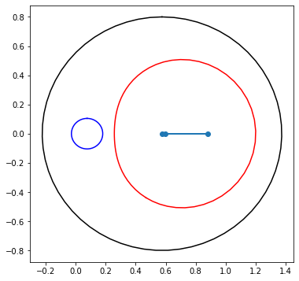

```python
# domain extension

a1 = critical_params[d]
f = Poly1(array([RR('1'), RR(a1)]), domain=(RR(0),RR(1)))
to_unit = Poly1([-c/r, RR(1)/r], domain=(c,r))
to_unit_inv = Poly1([c, r], domain=(c,r))
G0 = f(to_unit_inv)
print(G0)

def linspace(a, b, n):
    return np.array([(k*b + (n-1-k)*a)/(n-1) for k in range(n)])

from math import sin, cos

def sample_disc(c, r, num_points):
    data = []
    thetas = linspace(RR(0), RR(2*np.pi), num_points)
    Rs = linspace(RR(0), r, num_points)
    for R in r,:
        zs = np.array([c+R*Complex(sin(t), cos(t)) for t in thetas])
        data.append(zs)
    return data

def domain_extension(G):

    num_points = 64

    plt.figure(figsize=(6, 6))

    data = sample_disc(c, r, num_points)
    for zs in data:
        a = G(1)
        zads = [z*a**d for z in zs]
        QGzads = [Q(G(z)) for z in zads]

        for points, col in zip((zs, zads, QGzads), 'kbr'):
            plt.plot([z.re for z in points], [z.im for z in points], color=col)

    coords = [c, G(c*G(1)**d), Q(G(c*G(1)**d))]
    print(np.mean(coords))
    plt.plot(coords, [0, 0, 0], marker='o')

    plt.show()

domain_extension(G0)
```

```python
G1 = T(G0).truncate(N+1)
G2 = T(G1).truncate(N+1)
G3 = T(G2).truncate(N+1)
```

```python
G1
```

```
Poly1(coeffs=array([Decimal('-0.06909222655248886353039318803351155223984'),
       Decimal('-1.213651274557863421414403056471063409249'),
       Decimal('0.3465042006320100825501548661273752059497'),
       Decimal('-0.04396839102067560476058373729979581412562'),
       Decimal('0.002092203433703953706822189611284517981165'),
       Decimal('-0E-82'), Decimal('-0E-82'), Decimal('-0E-82')],
      dtype=object), domain=array([Decimal('0.5754'), Decimal('0.8')], dtype=object))
```

```python
G2
```

```
Poly1(coeffs=array([Decimal('-0.2433339898200968605134982418221834222380'),
       Decimal('-1.461066447341427219729410402288585661970'),
       Decimal('0.4629873083316738607406372291248814940833'),
       Decimal('0.05969626180806060874703695514129146208474'),
       Decimal('-0.07986118470323285546951655251961177562074'),
       Decimal('0.01996756382681973470053032178280021614844'),
       Decimal('0.0008636715081008688087386827855722145966406'),
       Decimal('-0.002043870097107602710992442195603557462163'),
       Decimal('0.0006809629764652555086798542693943685987173'),
       Decimal('-0.0001077030383135464172345626813407670739619'),
       Decimal('-0.000003513707804852571549696639275561194313696'),
       Decimal('0.000007599767762530770149321925660523225647225'),
       Decimal('-0.000002662024549279813612630787827564573271903'),
       Decimal('6.285327532930655343302973212624856018031E-7'),
       Decimal('-1.170536275190168795304843778873589118120E-7'),
       Decimal('1.819303392672151017069753431506014560714E-8'),
       Decimal('-2.427214437976964768203593777845543612311E-9'),
       Decimal('2.826513977319796926877435321484014528604E-10'),
       Decimal('-2.905313799551514270999004277605800377557E-11'),
       Decimal('2.657699372597999177332199790479283384703E-12'),
       Decimal('-2.177792366411666751892857707498478783311E-13'),
       Decimal('1.607261793524722670681270022968539946489E-14'),
       Decimal('-1.073398930707040497878302171383340837937E-15'),
       Decimal('6.514004678799554669826805169632955299992E-17'),
       Decimal('-3.605478247540585986901545664230416890545E-18'),
       Decimal('1.826227223052507874049990334628644641804E-19'),
       Decimal('-8.490311148327367981200116324899215238064E-21'),
       Decimal('3.632718022353505621950540693543612040529E-22'),
       Decimal('-1.433883506509472683971763641696098987242E-23'),
       Decimal('5.232215415616869320006531576960317016361E-25'),
       Decimal('-1.768277180744743981246724905292954116065E-26'),
       Decimal('5.543778544107119939388925292750996321468E-28'),
       Decimal('-1.614544898607565590462934844944306605073E-29'),
       Decimal('4.373065769427604391833716958482238318015E-31'),
       Decimal('-1.102619073770041066831982676471821825314E-32'),
       Decimal('2.589959142204929481366422822118269405105E-34'),
       Decimal('-5.670577428254131509785800117053483310965E-36'),
       Decimal('1.157667652798388159178698451211224836475E-37'),
       Decimal('-2.204118128511240690114156793779400786951E-39'),
       Decimal('3.913530675630479417098454084952310828518E-41'),
       Decimal('-6.478718014036884477553814290057137878850E-43')],
      dtype=object), domain=array([Decimal('0.5754'), Decimal('0.8')], dtype=object))
```

```python
Phi = make_Phi(F, DF)
```

```python
G = newton_steps(F, Phi, G0)
```

```
0.07628302603925941228746561500361648994363
0.002942252546515643806865031439035704267998
0.000001098279365633096807095263491202952757914
6.697800491583997813670804190787750610092E-13
2.53955184801607909634490252401605309E-25
5.736279982440938417052E-39
4.008745623623023385203E-39
3.971375434518473367717E-39
```

```python
G
```

```
Poly1(coeffs=array([Decimal('-0.0001511713350611291656840219741924513803728'),
       Decimal('-1.256390384839309113454966135865667953282'),
       Decimal('0.2468156475594798891903756058451096355452'),
       Decimal('0.05671913449535499518131217412581788560780'),
       Decimal('-0.03593899510003976630438282837116842900344'),
       Decimal('0.004309827907215549990447636871047240906414'),
       Decimal('0.001963541004817085940087254815745689472861'),
       Decimal('-0.0008943234149703396950331157425980735315547'),
       Decimal('0.00006105398965710550909210735250977441612747'),
       Decimal('0.00006188332027167695794768697217292717298129'),
       Decimal('-0.00002032064217816506082080381248250410325683'),
       Decimal('-5.917508310565041252387439151580871254779E-7'),
       Decimal('0.000001993110264488937754875003726939839127835'),
       Decimal('-4.460808064168219715750374754096584938983E-7'),
       Decimal('-7.091465500270745524324575719583669425079E-8'),
       Decimal('5.999985897082526939373691134821791750094E-8'),
       Decimal('-9.224090264909730396045855296354121978462E-9'),
       Decimal('-3.081048454699410800424424250663875788760E-9'),
       Decimal('1.652284575905043706736929645697526451124E-9'),
       Decimal('-1.530219765235557359683931463934319039528E-10'),
       Decimal('-1.096154081162629255139053111745887234700E-10'),
       Decimal('4.223753560176127120263526498938054598840E-11'),
       Decimal('-1.004640487249960190556471829234743826828E-12'),
       Decimal('-3.558676617626400441093094970696934322399E-12'),
       Decimal('1.004423856884389818875771912092651114756E-12'),
       Decimal('6.516615444194818766777972998731488911695E-14'),
       Decimal('-1.079237625624183863380047623840291084907E-13'),
       Decimal('2.172052736819717070611019669050637483423E-14'),
       Decimal('4.262632899226970967366030013560300636465E-15'),
       Decimal('-3.071110664243917246697097520762313221752E-15'),
       Decimal('3.978542434330043722816902947176104065343E-16'),
       Decimal('1.782851232460937282016199320668874345825E-16'),
       Decimal('-8.193352719716318716847908512520156175163E-17'),
       Decimal('4.678651669174662819847100066749610065839E-18'),
       Decimal('6.290977208505213125174399242621701562427E-18'),
       Decimal('-2.036602398263703289117227989144068623481E-18'),
       Decimal('-5.514501237092254757468581284250062671314E-20'),
       Decimal('2.007812537370097757999357628354024977398E-19'),
       Decimal('-4.634038429218728620855892635802171906372E-20'),
       Decimal('-6.570708157395334198926069248545061387139E-21'),
       Decimal('5.946190599987313954761299788512647909132E-21')],
      dtype=object), domain=array([Decimal('0.5754'), Decimal('0.8')], dtype=object))
```

```python
print(G(0))
print(G(1))
print(RR(1)/G(1))
```

```
1.000000000000000000000000000115767817839
-0.5916099166344381501396243579964057537198
-1.690302971405244853343780139996295310000
```

```
1.000000000000000000000000000115767817839
0.673845767075351785048633716539470435276
```

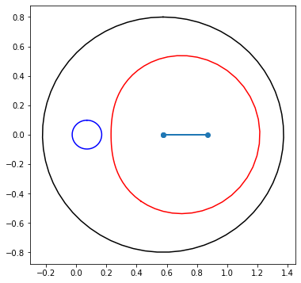

```python
# domain extension nonrigorously

print(G(0))
domain_extension(G)
```

```python
%matplotlib inline
import matplotlib.pyplot as plt
from numpy import linspace, array
```

To evaluate $G$ and $g=G\circ Q$ over larger domains, we use the fixed-point equation $$ G(X) = a^{-1}G(Q(G(a^dX))),\quad a:=G(1), $$ recursively.

```python
def G_full(X):
    X = RR(X)
    if abs(X-c) < r:
        return G(X)
    else:
        a = G(1)
        return a**-1*G_full(Q(G_full(a**d*X)))

def g_full(x):
    return G_full(x**d)
```

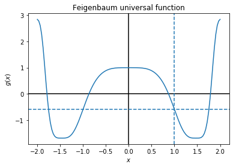

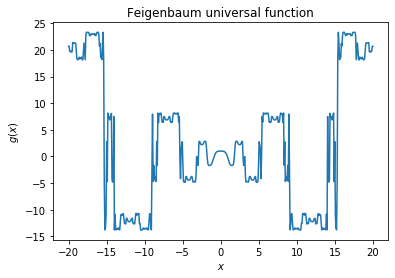

```python
if True: #draw_figures:
    x_vals = linspace(-2, 2, 128)
    y_vals = list(map(g_full, x_vals))

    plt.figure()
    plt.axvline(0, linestyle='-', color='k')
    plt.axhline(0, linestyle='-', color='k')
    plt.axvline(1, linestyle='--')
    plt.axhline(G(1), linestyle='--')
    plt.plot(x_vals, y_vals)
    plt.xlabel(r'$x$')
    plt.ylabel(r'$g(x)$')
    plt.title(r'Feigenbaum universal function')

    x_vals = linspace(-20, 20, 512)
    y_vals = list(map(g_full, x_vals))

    plt.figure()
    plt.plot(x_vals, y_vals)
    plt.xlabel(r'$x$')
    plt.ylabel(r'$g(x)$')
    plt.title(r'Feigenbaum universal function')

    plt.show()
```

```python
def G_full_depth(X, max_depth):
    if abs(X-c) < r:
        return G(X), 0
    else:
        if max_depth < 1:
            return 0, max_depth+1
        a = G(1)
        inner, d1 = G_full_depth(a**d*X, max_depth-1)
        outer, d2 = G_full_depth(Q(inner), max_depth-1)
        return a**-1*outer, max(d1, d2)+1
```

```python
for X0 in 0, 2, 5, 10, 20, 100:
    print(G_full_depth(X0, 2))
```

```
(Decimal('1.000000000000000000000000000115767817839'), 0)
(Decimal('-1.395212519657426899377967301705893365410'), 1)
(Decimal('-1.690268147780163411329327035801065587911'), 1)
(Decimal('-0.2029588805655746716078210329082320623047'), 1)
(Decimal('2.847134864782507293455007542270224698747'), 2)
(Decimal('2.217333459496650520333922651525833973076'), 3)
```

```python
# Feigenbaum constants to 1018 decimal places (case d=2 comparison)
#
#   From:  David Broadhurst  22-Mar-1999
#   To:    Simon Plouffe
#   CC:    Keith Briggs, David Bailey, Steven Finch
#   Subj:  Feigenbaum constants to 1018 decimal places
#
#
#  Keith Briggs' thesis gives values of alpha and delta to 576 decimal places.
#  I found that his values are good to 346 and 344 places, respectively.
#  The 1018 places below took 3 days, using 400MB on a 433MHz DECalpha,
#  with a collocation of N=700 points, checked in 3.5 days at N=720.
#  The Feigenbaum zero nearest to the origin was located to 1018 places.
#  The nearest complex singularity was located to 868 places.
#
#  Let g(x) and f(x) be even functions, with g(0)=f(0)=1
#
#                   g(alpha*x)/alpha = g(g(x))
#             delta*f(alpha*x)/alpha = g'(g(x))*f(x) + f(g(x))
#
#  and delta as large as possible. Let {b,c,d} be positive numbers with
#
#                          g(b) = 0 = 1/g(c+i*d)
#
#  and {b,c^2+d^2} as small as possible.
#
# ADB: c and d are as follows:-

# zero nearest the origin
sing_b = 0.832367236905316424849095446276104487378444151012251178801815…

# real part of singularity nearest the origin
sing_c = 1.831258984937131485342173397873781627441298090376237965477411…

#imaginary part of singularity nearest the origin
sing_d = 2.683150900474071801449936758645148251038610920554435493093680…
```

```python
import numpy as np

tiles = 4
max_depth = 8
xcen, ycen, rad = 0, 0, 100
xmin, xmax = xcen-rad, xcen+rad
ymin, ymax = ycen-rad, ycen+rad
xsteps = ysteps = 512
b_vals = [(j/ysteps)*ymax + (1-j/ysteps)*ymin for j in range(ysteps+1)]
a_vals = [(k/xsteps)*xmax + (1-k/xsteps)*xmin for k in range(xsteps+1)]
power_for_analyticity = 1

def compute_depth(index):
    J, K = index//tiles, index%tiles
    A, B = a_vals[J::tiles], b_vals[K::tiles]
    v = np.zeros((len(B), len(A)), dtype=int)
    for j, b in enumerate(B):
        for k, a in enumerate(A):
            z = Complex(a, b)
            gz, depth = G_full_depth(z**power_for_analyticity, max_depth)
            v[j, k] = depth
    return v
```

```python
if draw_figures:
    xmin, xmax, ymin, ymax = xcen-rad, xcen+rad, ycen-rad, ycen+rad
    v = np.zeros((ysteps+1, xsteps+1), dtype=int)
    power_for_analyticity = 1
    from pathos.multiprocessing import Pool
    pool = Pool(7)
    indices = list(range(tiles**2))
    depths = pool.map(compute_depth, indices)
    for index, depth in enumerate(depths):
        J, K = index//tiles, index%tiles
        v[K::tiles,J::tiles] = depth
```

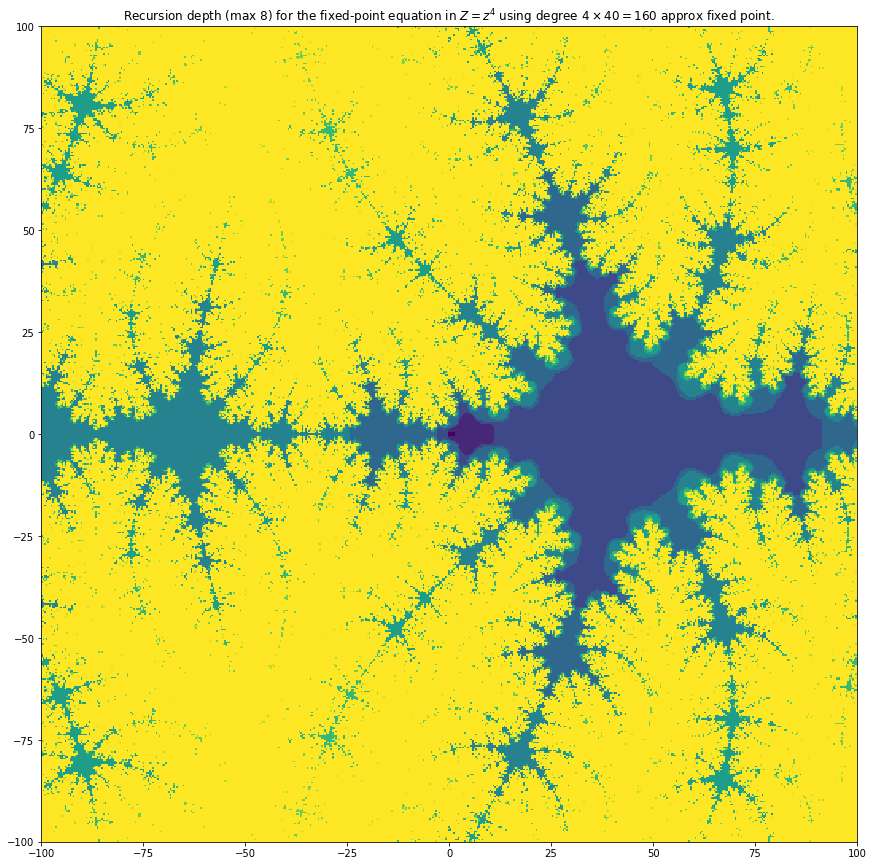

```python
if draw_figures:
    %matplotlib inline
    import matplotlib.pyplot as plt

    plt.figure(figsize=(15,15))
    plt.title(f'Recursion depth (max ${max_depth}$) for the fixed-point equation in $Z=z^{d}$ using degree ${d}\\times{N}={d*N}$ approx fixed point.')
    plt.imshow(v, cmap='viridis', extent=(xcen-rad, xcen+rad, ycen-rad, ycen+rad))
    #sing = Complex(sing_c, sing_d)
    #Qsing = sing**d
    #plt.plot([Qsing.re], [Qsing.im], color='w', marker='o')
    plt.xlim(xcen-rad, xcen+rad)
    plt.ylim(xcen-rad, xcen+rad)
    plt.savefig(f'fig/analyticity_pow{d}_deg{N}_depth{max_depth}_zdrep.png')
    plt.show()
```

Previously-computed image ($d=2$) for comparison:

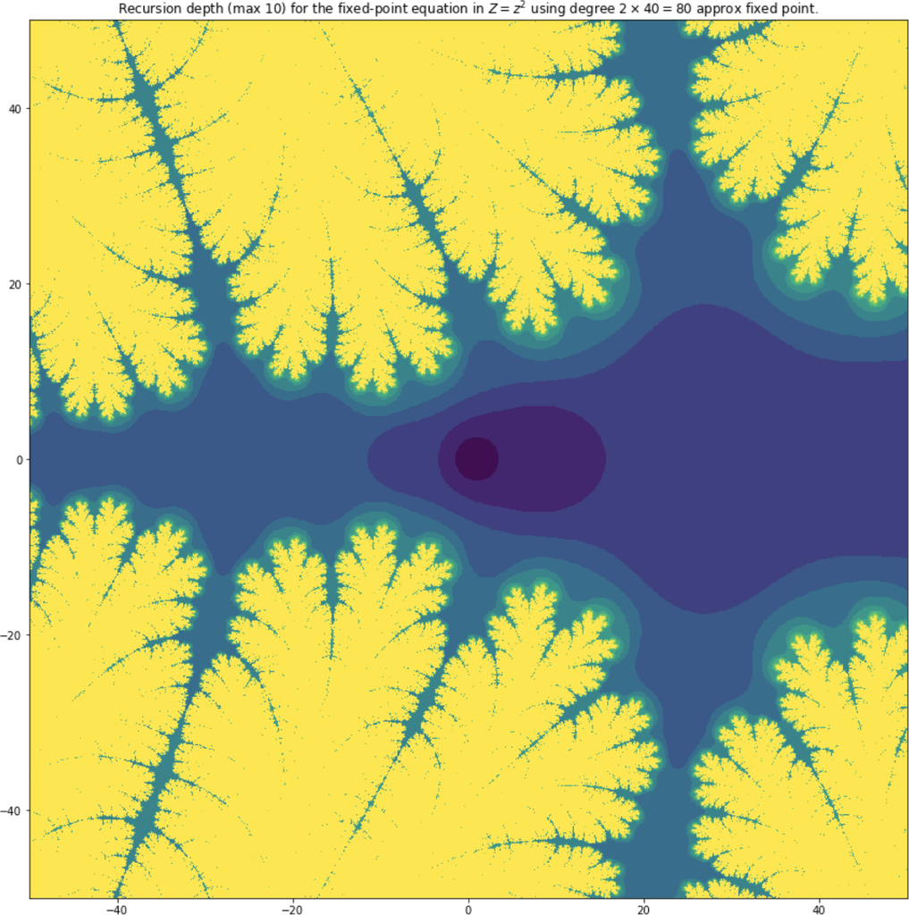

Note that we also do this rigorously, with rectangle arithmetic, although it is computationally very intensive; certain regions will take a large number of iterations to be reached and the looseness of interval and rectangle bounds mean that only a subset of the domain can be explored this way.

```python
if draw_figures:
    max_depth = 7
    xcen, ycen, rad = 0, 0, 4
    xmin, xmax, ymin, ymax = xcen-rad, xcen+rad, ycen-rad, ycen+rad
    xsteps = ysteps = 512
    b_vals = [(j/ysteps)*ymax + (1-j/ysteps)*ymin for j in range(ysteps+1)]
    a_vals = [(k/xsteps)*xmax + (1-k/xsteps)*xmin for k in range(xsteps+1)]
    w = np.zeros((ysteps+1, xsteps+1), dtype=int)
    power_for_analyticity = d

    from pathos.multiprocessing import Pool
    pool = Pool(7)
    indices = list(range(tiles**2))
    depths = pool.map(compute_depth, indices)
    for index, depth in enumerate(depths):
        J, K = index//tiles, index%tiles
        w[K::tiles,J::tiles] = depth
```

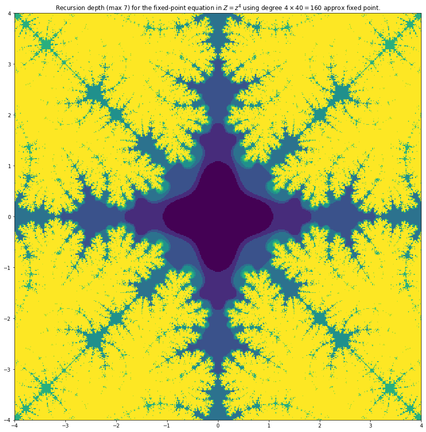

```python
if draw_figures:
    plt.figure(figsize=(15,15))
    plt.title(f'Recursion depth (max ${max_depth}$) for the fixed-point equation in $Z=z^{d}$ using degree ${d}\\times{N}={d*N}$ approx fixed point.')
    plt.imshow(w, cmap='viridis', extent=(xcen-rad, xcen+rad, ycen-rad, ycen+rad))
    if d == 2:
        plt.plot([0, sing_c], [0, sing_d], color='w', marker='o')
        plt.plot([sing_c], [sing_d], color='k', marker='.')
    plt.xlim(xcen-rad, xcen+rad)
    plt.ylim(xcen-rad, xcen+rad)
    plt.savefig(f'fig/analyticity_pow{d}_deg{N}_depth{max_depth}.png')
    plt.show()
```

For comparison, see the following image from Buff, in the case of degree $d=2$ critical point:

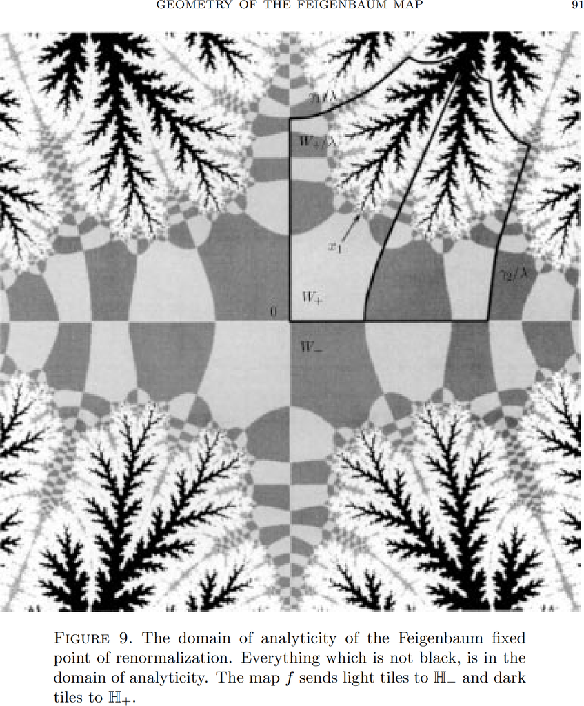

```python
for (k, a_k) in enumerate(G.coef):
    print(k, a_k)
```

```
0 -0.0001511713350611291656840219741924513803728
1 -1.256390384839309113454966135865667953282
2 0.2468156475594798891903756058451096355452
3 0.05671913449535499518131217412581788560780
4 -0.03593899510003976630438282837116842900344
5 0.004309827907215549990447636871047240906414
6 0.001963541004817085940087254815745689472861
7 -0.0008943234149703396950331157425980735315547
8 0.00006105398965710550909210735250977441612747
9 0.00006188332027167695794768697217292717298129
10 -0.00002032064217816506082080381248250410325683
11 -5.917508310565041252387439151580871254779E-7
12 0.000001993110264488937754875003726939839127835
13 -4.460808064168219715750374754096584938983E-7
14 -7.091465500270745524324575719583669425079E-8
```

[output cut: 26 more lines]

#### Evaluating the derivative of $G$ over larger domains

We can use the fixed-point equation for $G$: \begin{equation} G(X) = a^{-1}G(Q(G(a^dX))). \end{equation} Differentiating gives \begin{equation} G'(X) = a^{-1}G'(Q(G(a^2X)))\cdot Q'(G(a^dX))\cdot G'(a^dX)\cdot a^d. \end{equation} Using the above expression (together with the fixed-point equation for $G$) recursively allows us to bound $G'$ over larger intervals extending outside $\Omega$.

```python
Gdash = G.deriv()

def Gdash_full(X):
    X = RR(X)
    if abs(X-c) < r:
        return Gdash(X)
    else:
        a = G(1)
        adX = a**d*X
        GadX = G_full(adX)
        QGadX = Q(GadX)
        return a**-1*Gdash_full(QGadX)*d*GadX**(d-1)*Gdash_full(adX)*a**d

def gdash_full(x):
    x = RR(x)
    return Gdash_full(x**d)*d*x**(d-1)
```

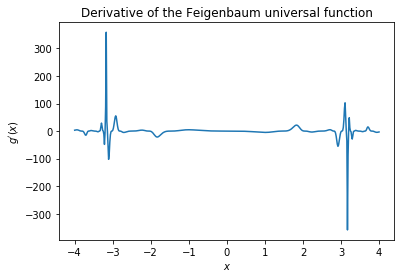

```python
if draw_figures:
    x_vals = linspace(-4, 4, 512)
    y_vals = list(map(gdash_full, x_vals))

    plt.figure()
    plt.plot(x_vals, y_vals)
    plt.xlabel(r'$x$')
    plt.ylabel(r"$g'(x)$")
    plt.title(r'Derivative of the Feigenbaum universal function')
    plt.show()
```

## Universal eigenfunction corresponding to delta

### The eigenproblem

We now aim to get rigorous bounds on eigenfunction-eigenvalue pairs $(V, \lambda)$: we need to solve the equation \begin{align} D\mathbb{T}(G)V &= \lambda V, \end{align} which we abbreviate to \begin{align} LV &= \lambda V. \end{align} For eigenfunctions we insist that $V\not\equiv 0$ and thus there is a minimum $k$ such that $\phi_k(V)\neq 0$, where $\phi_k$ denotes the $k$-th coordinate functional with respect to our chosen basis. We may then encode the eigenvalue $\lambda$ within the eigenfunction $V$ by writing $\phi=\phi_k$ and \begin{align} (V, \lambda)\mapsto \lambda\frac{V}{\phi(V)}, \end{align} and then solving the corresponding nonlinear problem given by \begin{align} LV &= \phi(V)V. \end{align} Accordingly, we seek a zero of the corresponding operator \begin{align} F(V) &:= LV - \phi(V)V, \end{align} which has Frechet derivative given formally by \begin{align} DF(V)\delta V &= L\delta V - \phi(\delta V)V - \phi(V)\delta V. \end{align}

As an initial guess, $V^0$, we compute approximate eigenvalues and eigenvectors for the matrix elements of $DT(G)$ at the approximate fixed point found above, up to our truncation degree.

```python
Delta = matrix_elements(DT(G))
```

```python
Lambda = inv(Delta - identity(N+1))
```

```python
from numpy.linalg import eig
vals, vecs_T = eig([[float(elt) for elt in row] for row in Delta])
for j, val in enumerate(vals):
    print(j, val)
```

```
0 8.163158323607487
1 7.2846862170733555
2 0.2918384089835413
3 -0.2556645584742872
4 -0.15556276184340104
5 0.12250160542740547
6 -0.07372028667560959
7 0.04302851883343182
8 -0.02570976508112263
9 0.015006643332291547
10 -0.008937874412310962
11 0.005251575462679501
12 -0.0031176525488550524
13 0.0018383379002854326
14 -0.001089193634092202
```

[output cut: 26 more lines]

```python
1/G(1)**d
```

```
Decimal('8.163158323607492932358695975878081117234')
```

```python
j = 1
vecj, valj = vecs_T.T[j].real, vals[j].real
vecj = array([RR(elt) for elt in vecj], dtype=RR)
valj = RR(valj)
```

```python
def phi(v):
    assert isinstance(v, Poly1)
    return v.coef[0]
```

```python
print(phi(G))
print(G(1))
```

```
-0.0001511713350611291656840219741924513803728
-0.5916099166344381501396243579964057537198
```

```python
print(RR(1)/G(1))
```

```
-1.690302971405244853343780139996295310000
```

```python
def make_V(vec, val):
    return Poly1(val*vec/vec[0], domain=(c,r))
```

```python
V1_0 = make_V(vecj, valj)
```

```python
# starting point for delta - don't expect much from the number in this cell
phi(V1_0)
```

```
Decimal('7.284686217073355507523046981077641248703')
```

```python
DTG = DT(G)

def F_hat(V):
    return DTG(V) - phi(V)*V

def DF_hat(V):
    def DF_hat_V(dV):
        return DTG(dV) - phi(dV)*V - phi(V)*dV
    return DF_hat_V

DTG_naive = DT_naive(G)

def F_hat_naive(V):
    return DTG_naive(V) - phi(V)*V

def DF_hat_naive(V):
    def DF_hat_V_naive(dV):
        return DTG_naive(dV) - phi(dV)*V - phi(V)*dV
    return DF_hat_V_naive
```

```python
Phi_hat = make_Phi(F_hat, DF_hat)
```

```python
V1 = newton_steps(F_hat, Phi_hat, V1_0)
print(phi(V1))
```

```
4.78445603601518173945953114894E-28
2.4021442215578525162E-38
7.284686217073343364308928771520785880120
```

```python
Phi_hat_naive = make_Phi(F_hat_naive, DF_hat_naive)
```

```python
V1_naive = newton_steps(F_hat_naive, Phi_hat_naive, V1_0)
print(f'eigenvalue estimate = {phi(V1_naive)}')
```

```
8.805594988610159324492464588275699329897E-13
1.3238574751048430693839631932554E-26
1.4250898343394028672E-38
1.2140314218112542276E-38
4.220105318678276644E-39
1.000223202097109609E-39
1.000124418766944103E-39
1.000003343649901681E-39
eigenvalue estimate = 7.284686217073343364308930803707779982963
```

### Evaluating the eigenfunction on larger intervals

Finally, combining the fixed-point equation for $G$, the recurrence for $G'$, and the recurrence for $V$ shown here, \begin{align} V(X) &= \delta^{-1}DT(G)V(X)\\ &= \delta^{-1}\bigl[-a^{-2}\delta \cdot G(Q(G(a^dX)))\\ &\quad{}+ a^{-1}\cdot V(Q(G(a^dX)))\\ &\qquad{}+ a^{-1}\cdot G'(Q(G(a^dX)))\cdot Q'(G(a^dX))\cdot V(a^dX)\\ &\qquad\quad{}+ a^{-1}\cdot G'(Q(G(a^dX)))\cdot Q'(G(a^dX))\cdot G'(a^dX)\cdot Q'(a)\delta\cdot X\bigr], \end{align} where $a:=G(1)$ and $\delta:=\phi(V)$, allows us to evaluate the eigenfunction $V(X)$ itself, and hence $v(x)=V(x^d)$, the corresponding eigenfunction for the derivative of the original renormalisation operator (rather than our even representation), over larger subintervals of the real line.

```python
def make_recursive_DTG_eigenfunction(V):

    def V_full(X):
        X = RR(X)
        if abs(X-c) < r:
            return V(X)

        a = G(1)
        Xad = X*a**d
        GXad = G_full(Xad)
        QGXad = Q(GXad)
        GQGXad = G_full(QGXad)

        GdashXad = Gdash_full(Xad)
        GdashQGXad = Gdash_full(QGXad)

        da = V(1)
        term1 = -a**-2*da*GQGXad
        term2 = a**-1*V_full(QGXad)
        term3 = a**-1*GdashQGXad*d*GXad**(d-1)*V_full(Xad)
        term4 = a**-1*GdashQGXad*d*GXad**(d-1)*GdashXad*d*a**(d-1)*da*X
        lhs = term1 + term2 + term3 + term4

        # don't forget to divide by the eigenvalue below
        return lhs/phi(V)

    def v_full(x):
        x = RR(x)
        return V_full(x**d)

    return V_full, v_full
```

```python
def make_recursive_DTG_naive_eigenfunction(V):

    def V_full(X):
        X = RR(X)
        if abs(X-c) < r:
            return V(X)

        a = G(1)
        Xad = X*a**d
        GXad = G_full(Xad)
        QGXad = Q(GXad)
        GQGXad = G_full(QGXad)

        GdashXad = Gdash_full(Xad)
        GdashQGXad = Gdash_full(QGXad)

        da = V(1)
        term2 = a**-1*V_full(QGXad)
        term3 = a**-1*GdashQGXad*d*GXad**(d-1)*V_full(Xad)
        lhs = term2 + term3

        # don't forget to divide by the eigenvalue below
        return lhs/phi(V)

    def v_full(x):
        x = RR(x)
        return V_full(x**d)

    return V_full, v_full
```

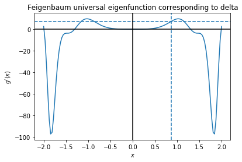

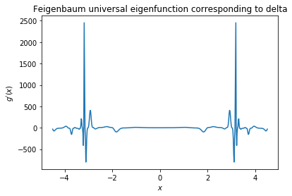

```python
V1_full, v1_full = make_recursive_DTG_eigenfunction(V1)

if draw_figures:
    x_vals = linspace(-2, 2, 128)
    y_vals = list(map(v1_full, x_vals))

    plt.figure()
    plt.plot(x_vals, y_vals)
    plt.axvline(c**(1/RR(d)), linestyle='--')
    plt.axhline(phi(V1), linestyle='--')
    plt.axvline(0, linestyle='-', color='k')
    plt.axhline(0, linestyle='-', color='k')
    plt.xlabel(r'$x$')
    plt.ylabel(r"$g'(x)$")
    plt.title(r'Feigenbaum universal eigenfunction corresponding to delta')

    x_vals = linspace(-4.5, 4.5, 512)
    y_vals = list(map(v1_full, x_vals))

    plt.figure()
    plt.plot(x_vals, y_vals)
    plt.xlabel(r'$x$')
    plt.ylabel(r"$g'(x)$")
    plt.title(r'Feigenbaum universal eigenfunction corresponding to delta')

    plt.show()
```

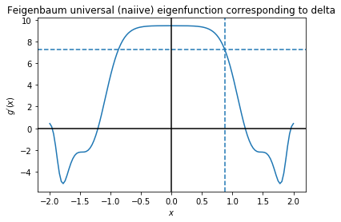

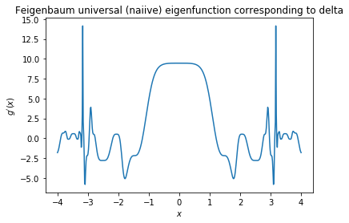

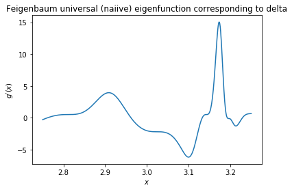

```python
V1_naive_full, v1_naive_full = make_recursive_DTG_naive_eigenfunction(V1_naive)

if draw_figures:
    x_vals = linspace(-2, 2, 128)
    y_vals = list(map(v1_naive_full, x_vals))

    plt.figure()
    plt.plot(x_vals, y_vals)
    plt.axvline(c**(1/RR(d)), linestyle='--')
    plt.axhline(phi(V1), linestyle='--')
    plt.axvline(0, linestyle='-', color='k')
    plt.axhline(0, linestyle='-', color='k')
    plt.xlabel(r'$x$')
    plt.ylabel(r"$g'(x)$")
    plt.title(r'Feigenbaum universal (naiive) eigenfunction corresponding to delta')

    x_vals = linspace(-4, 4, 512)
    y_vals = list(map(v1_naive_full, x_vals))

    plt.figure()
    plt.plot(x_vals, y_vals)
    plt.xlabel(r'$x$')
    plt.ylabel(r"$g'(x)$")
    plt.title(r'Feigenbaum universal (naiive) eigenfunction corresponding to delta')

    x_vals = linspace(2.75, 3.25, 512)
    y_vals = list(map(v1_naive_full, x_vals))

    plt.figure()
    plt.plot(x_vals, y_vals)
    plt.xlabel(r'$x$')
    plt.ylabel(r"$g'(x)$")
    plt.title(r'Feigenbaum universal (naiive) eigenfunction corresponding to delta')

    plt.show()
```

```python
# eigenfunction for naive 1 or full a**-2
def e1(x):
    x = RR(x)
    return x*gdash_full(x) - g_full(x)
```

```python
a = g_full(1)
delt = v1_naive_full(1)
s = delt/(a*(delt-a**-2))

def v1_naive_converted_to_full(x):
    return v1_naive_full(x) + s*e1(x)

def v1_naive_converted_to_full_normalized(x):
    return v1_naive_converted_to_full(x)*delt/v1_naive_converted_to_full(1)
```

```python
print(phi(V1_naive))
```

```
7.284686217073343364308930803707779982963
```

```python
for (k, a_k) in enumerate(V1.coef):
    print(k, a_k)
```

```
0 7.284686217073343364308928771520785880120
1 7.166839843174802185240992572993248655458
2 -5.433001676297059973591004034310118629630
3 -0.8162303438668710530428311222016364703596
4 1.274860776188583447864516599295497048418
5 -0.2771613530843119823286503894709891517532
6 -0.08203153501419121617226533778780391517846
7 0.05969385630085114964753544763528078527220
8 -0.007968162367437230733794459341825886155262
9 -0.004473236961734716925259770570702585699940
10 0.002083437510864333652580812184674161939691
11 -0.00006645640022933414159232408151728977355432
12 -0.0002099312322013898646500738828835093459824
13 0.00006425601109949456465339060112578971537033
14 0.000005096246796708563286762743565102657246630
```

[output cut: 26 more lines]

```python
j = 0
vecj, valj = vecs_T.T[j].real, vals[j].real

V0_0 = make_V(vecj, valj)
```

```python
V0 = newton_steps(F_hat, Phi_hat, V0_0)
```

```
2.32272999554491989001719869891E-28
1.4022273139774275459E-38
```

```python
print(phi(V0))
print(G(1)**(-2))
```

```
8.163158323607492932358697907491078067540
2.857124135141400000343125101174689656686
```

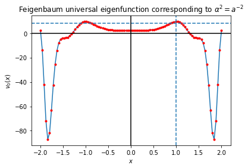

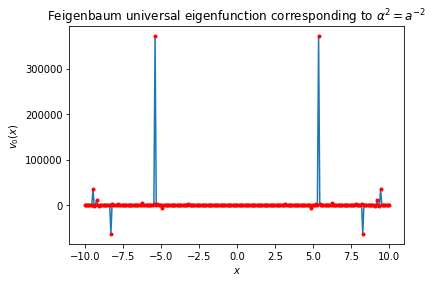

```python
V0_full, v0_full = make_recursive_DTG_eigenfunction(V0)

if draw_figures:
    # the function e1 is both:
    # an eigenfunction for DTG_naive with eigenvalue 1, and
    # an eigenfunction for DTG with eigenvalue a**-2
    # here, we compare them

    x_vals = linspace(-2, 2, 100)
    y_vals = list(map(v0_full, x_vals))
    z_vals = array(list(map(e1, x_vals)))*v0_full(0)/e1(0)

    plt.figure()
    plt.plot(x_vals, y_vals)
    plt.plot(x_vals, z_vals, marker='.', color='r', linewidth=0)
    plt.axvline(1, linestyle='--')
    plt.axhline(phi(V0), linestyle='--')
    plt.axvline(0, linestyle='-', color='k')
    plt.axhline(0, linestyle='-', color='k')
    plt.xlabel(r'$x$')
    plt.ylabel(r"$v_0(x)$")
    plt.title(r'Feigenbaum universal eigenfunction corresponding to $\alpha^2=a^{-2}$')

    x_vals = linspace(-10, 10, 256)
    y_vals = list(map(v0_full, x_vals))
    z_vals = array(list(map(e1, x_vals)))*v0_full(0)/e1(0)

    plt.figure()
    plt.plot(x_vals, y_vals)
    plt.plot(x_vals, z_vals, marker='.', color='r', linewidth=0)
    plt.xlabel(r'$x$')
    plt.ylabel(r"$v_0(x)$")
    plt.title(r'Feigenbaum universal eigenfunction corresponding to $\alpha^2=a^{-2}$')

    plt.show()
```

## Universal noise eigenfunction

### Noise eigenproblem in the even representation

Writing $\theta = K\circ Q$, we consider the following nonlinear eigenproblem

$$ \gamma^2K = \mathscr{L}K, $$

where we define $\gamma=\phi(K)$ and

$$ \mathscr{L}K = a^{-2}\left[ \bigl(G'(Q(G(a^2X)))\cdot 2G(a^2X)\bigr)^2K(a^2X) + K(Q(G(a^2X))) \right], $$

this leads to the following operator

$$ \mathscr{F}(K) = \mathscr{L}K - \phi(K)^2K. $$

Taking the Frechet derivative acting on a perturbation $\delta K$ yields

\begin{align} D\mathscr{F}(K)\delta K = \mathscr{L}\delta K - 2\phi(K)\phi(\delta K)K - \phi(K)^2\delta K. \end{align}

Again, we perform Newton's method numerically to find a good approximate fixed point $K^0$ on a suitable domain.

In order to start the method, we take a crude approximation to the eigenvalue, and normalise a similarly-crude affine approximation to $K$:

```python
noise_coeffs = {2: -1.5,
                4: -1.7}

Vn = Poly1([1, noise_coeffs[d]], domain=(0,1))
Vn0 = Vn(to_unit_inv)
Vn0(0), Vn0(1)
```

```
(Decimal('1.000000000000000000000000000000000000000'),
 Decimal('-0.6999999999999999555910790149937383830550'))
```

```python
print(Vn0)
```

```
Poly1(coeffs=array([Decimal('0.0218200000000000255528931347726029343902'),
       Decimal('-1.359999999999999964472863211994990706444')],
      dtype=object), domain=array([Decimal('0.5754'), Decimal('0.8')], dtype=object))
```

```python
val_approx = RR('8.6')
V_noise_0 = Vn0/phi(Vn0)*val_approx
print(V_noise_0)
```

```
Poly1(coeffs=array([Decimal('8.6'),
       Decimal('-536.0219981668187899887161585316363918049')],
      dtype=object), domain=array([Decimal('0.5754'), Decimal('0.8')], dtype=object))
```

```python
def make_noise(G):
    a = G(1)
    X = G.identity(domain=G.domain)
    Xad = X*a**d
    GXad = G(Xad)
    QGXad = Q(GXad)
    GQGXad = G(QGXad)

    Gdash = G.deriv()
    GdashXad = Gdash(Xad)
    GdashQGXad = Gdash(QGXad)

    t2 = (a**-1)**2
    t3 = ((a**-1*GdashQGXad*d*GXad**(d-1))**2).truncate(N+1)

    def T_noise(H):
        assert all(G.domain == H.domain)
        term2 = t2*H(QGXad)
        term3 = t3*H(Xad)
        lhs = term2 + term3
        return lhs #.truncate(N+1)

    def F_noise(H):
        assert all(G.domain == H.domain)
        lhs = T_noise(H)
        rhs = phi(H)**2*H
        return (lhs - rhs) #.truncate(N+1)

    def DF_noise(H):
        def DF_noise_H(K):
            assert all(K.domain == H.domain)
            term2 = t2*K(QGXad)
            term3 = t3*K(Xad)
            lhs = term2 + term3
            rhs = 2*phi(H)*phi(K)*H + phi(H)**2*K
            return (lhs - rhs) #.truncate(N+1)
        return DF_noise_H

    return T_noise, F_noise, DF_noise
```

```python
T_noise, F_noise, DF_noise = make_noise(G)
Phi_noise = make_Phi(F_noise, DF_noise)
```

```python
V_noise = newton_steps(F_noise, Phi_noise, V_noise_0)
```

```
107.2605132368033582238286263680538582054
12.88600725590765184006824520183740605859
0.2034509115874950297311157356260046536605
0.00004546508392458612657029585419211026056924
2.090481792066178091542135913904286907701E-12
4.202362674600437105401376331E-27
3.72033141128834003E-37
```

```python
print(phi(V_noise))
```

```
8.243910854252586818398468140727485681598
```

### Evaluating the noise eigenfunction on larger intervals

```python
def V_noise_full(X):
    X = RR(X)
    if abs(X-c) <= r:
        return V_noise(X)
    else:
        a = G(1)
        adX = a**d*X
        GadX = G_full(adX)
        QGadX = Q(GadX)
        GQGadX = G_full(QGadX)

        GdashadX = Gdash_full(adX)
        GdashQGadX = Gdash_full(QGadX)

        term2 = (a**-1)**2*V_noise_full(QGadX)
        term3 = (a**-1*GdashQGadX*d*GadX**(d-1))**2*V_noise_full(adX)
        lhs = term2 + term3
        # don't forget to divide by the square of the eigenvalue;
        # the operator stands for two noisy iterations
        return lhs/phi(V_noise)**2

def v_noise_full(x):
    x = RR(x)
    return V_noise_full(x**d)
```

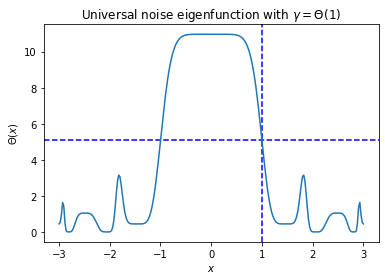

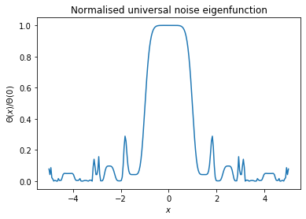

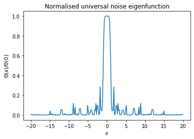

```python
if draw_figures:
    x_vals = linspace(-3, 3, 256)
    y_vals = array(list(map(v_noise_full, x_vals)))

    plt.figure()
    plt.axvline(1, linestyle='--', color='b')
    plt.axhline(V_noise(1), linestyle='--', color='b')
    plt.plot(x_vals, y_vals)
    plt.xlabel(r'$x$')
    plt.ylabel(r'$\Theta(x)$')
    plt.title(r'Universal noise eigenfunction with $\gamma=\Theta(1)$')

    x_vals = linspace(-5, 5, 256)
    y_vals = array(list(map(v_noise_full, x_vals)))

    plt.figure()
    plt.plot(x_vals, y_vals/V_noise(0))
    plt.xlabel(r'$x$')
    plt.ylabel(r'$\Theta(x)/\Theta(0)$')
    plt.title(r'Normalised universal noise eigenfunction')

    x_vals = linspace(-20, 20, 256)
    y_vals = array(list(map(v_noise_full, x_vals)))

    plt.figure()
    plt.plot(x_vals, y_vals/V_noise(0))
    plt.xlabel(r'$x$')
    plt.ylabel(r'$\Theta(x)/\Theta(0)$')
    plt.title(r'Normalised universal noise eigenfunction')

    plt.show()
```

```python
print(phi(V_noise))
```

```
8.243910854252586818398468140727485681598
```

```python
print(V_noise(1))
```

```
5.083829531656720815724083917541877195504
```

```python
for (k, a_k) in enumerate(V_noise.coef):
    print(k, a_k)
```

```
0 8.243910854252586818398468140727485681598
1 -6.032269284842356590763124761811898139329
2 -0.9982018393488768212870485551214219254660
3 2.636380035575487901277173048576548376450
4 -0.8141796198214493447765290740007908803075
5 -0.2914776696974148421740854390292029094745
6 0.2745372070550113999541623636218775331978
7 -0.04633125714306393162354991190342385865219
8 -0.03001770434187098209852408805452277230873
9 0.01747406108159697558619274593825089242219
10 -0.001244840016483334494990914000047655701907
11 -0.002110046728570736484967808324450109239034
12 0.0008333458172130182896109355805611670049736
13 0.00002863679588472385117810330721347044424686
14 -0.0001189318818323646555212827708240243473603
```

[output cut: 26 more lines]

```python
Lambda_noise = inv(matrix_elements(DF_noise(V_noise)))
```

## Collecting universal constants

```python
g0 = G(0)
a = G(1)
alpha = RR(1)/a
delta = phi(V1)
gamma = phi(V_noise)

print(g0)
print(a)
print(alpha)
print(delta)
print(gamma)
```

```
1.000000000000000000000000000115767817839
-0.5916099166344381501396243579964057537198
-1.690302971405244853343780139996295310000
7.284686217073343364308928771520785880120
8.243910854252586818398468140727485681598
```

## Exporting data for rigorous proof

### Exporting polynomials with domains

Below, we provide code for exporting a poly and domain, ready for use in the rigorous code.

```python
def export_poly(p, filename):
    c, r = p.domain
    coeffs = list(map(RR, p.coef))
    truncation_degree = len(coeffs)-1
    with open(filename, 'w') as f:
        f.write(f'{c}\n')
        f.write(f'{r}\n')
        f.write(f'{truncation_degree}\n')
        for coeff in coeffs:
            f.write(f'{coeff}\n')
```

```python
export_poly(G, f'dat/feig_pow{d}_deg{N}_domain1_G0.dat')
export_poly(V1, f'dat/feig_pow{d}_deg{N}_domain1_V10.dat')
export_poly(V0, f'dat/feig_pow{d}_deg{N}_domain1_V00.dat')
export_poly(V_noise, f'dat/feig_pow{d}_deg{N}_domain1_K0.dat')
```

### Exporting matrices

```python
def export_matrix(A, filename):
    m, n = shape(A)
    assert m == n
    with open(filename, 'w') as f:
        f.write(f'{m}\n')
        f.write(f'{n}\n')
        for j in range(m):
            f.write(' '.join(map(str, map(RR, A[j])))+'\n')
```

```python
export_matrix(Delta, f'dat/feig_pow{d}_deg{len(Delta)-1}_domain1_delta.dat')
export_matrix(Lambda, f'dat/feig_pow{d}_deg{N}_domain1_lambda.dat')
export_matrix(Lambda_noise, f'dat/feig_pow{d}_deg{N}_domain1_lambda_noise.dat')
```

## Report on packages used

```python
import sys
import decimal
import pathos

print(f'python=={sys.version}')
print(f'decimal=={decimal.__version__}')
print(f'pathos=={pathos.__version__}')

import matplotlib
import numpy

print(f'numpy=={np.__version__}')
print(f'matplotlib=={matplotlib.__version__}')
```

```
python==3.7.4 (default, Aug 13 2019, 20:35:49)
[GCC 7.3.0]
decimal==1.70
pathos==0.2.3
numpy==1.18.1
matplotlib==3.1.3
```